# Import Python Libraries

```python
import pandas as pd
import numpy as np
import matplotlib.pyplot as plt

import mat4py # .mat file conversion

from scipy.signal import welch, find_peaks # Signal Processing

import stumpy # Matrix Profile
from stumpy.floss import _cac # One sided cac

import ot # Optimal Transport

from vmdpy import VMD # Variational Mode Decomposition

from ruptures.metrics import hausdorff # Quantifying Break Point Discrepancies

# Utils
import time
import os
loc = os.getcwd()

# Matplotlib Params
import matplotlib
font = {'family' : 'DejaVu Sans',
        'weight' : 'bold',
        'size'   : 16}

matplotlib.rc('font', **font)

# Note for me:
# Should we consider a sub-study where we take subsets of the 24 sensors and study the effect of adding more and more sensors?
# Possible smaller conf paper (we did this for original DSTG grant but we have too many things to talk about now
# so save for next time?)
```

# Building Data Pre-Processing

```python
# Checking keys
data = mat4py.loadmat('Building_Model.mat')
print(data.keys())
```

```
dict_keys(['SensorList', 'nSensors', 'EventIDs', 'X', 'nTests', 'nDamagedTests', 'nHealthyTests', 'EventSizes', 'labels_binary', 'F'])
```

```python
# Extracting relevant values (based on keys)
nTests = data['nTests']
nHealthy = data['nHealthyTests']
nDamage = data['nDamagedTests']
nSensors = data['nSensors']
X = data['X']

# Making informative columns names (for pandas data frame)
info_cols = ['y_labels','damage_location','damage_level','voltage_level']
X_cols_time = ['Xt_'+str(i) for i in range(len(X[0]))]
cols = [X_cols_time + info_cols]

# Data info
signal_length = 8192   # Counts
fs = 1600 # Hz
total_time = 8192 / 1600 # 5.12 seconds
num_sensors = 24 # Total number of sensors
```

```python
print('Total number of sensors: '+str(nSensors))
print('Total number of tests: '+str(nTests))
print('Total number of instances: '+str(len(X))) # There are 24 sensors x 270 events = 6480 instances
print('Length of each data recording: '+str(len(X[0]))) # Each data recording is 8192 long
```

```
Total number of sensors: 24
Total number of tests: 270
Total number of instances: 6480
Length of each data recording: 8192
```

### Organizing data to be in dictionary structure

```python
time_start = time.time()

data_dict = {}
for i in range(1,nSensors+1):

    # Extracting Data
    X_time = X[nTests*(i-1):nTests*i]
    y = data['labels_binary'][nTests*(i-1):nTests*i]
    locations = [ L[0][0:3] for L in data['EventIDs'][nTests*(i-1):nTests*i] ]
    damage_levels = [ L[0][4:7] for L in data['EventIDs'][nTests*(i-1):nTests*i] ]
    shaker_voltage = [ L[0][8:11] for L in data['EventIDs'][nTests*(i-1):nTests*i] ]

    # Building Lists for Pandas
    sensor_data = []
    for j in range(len(X_time)):
        sensor_data.append(X_time[j]+y[j]+[locations[j]]+[damage_levels[j]]+[shaker_voltage[j]])

    # Constructing DataFrame
    sensor_time_df = pd.DataFrame(data=sensor_data, columns=cols)
    data_dict['Sensor'+str(i)] = sensor_time_df

    print(f'Data processed for sensor {i}.')

time_end = time.time()

print(f'Time Taken: {time_end-time_start:.2f}s')
```

```
Data processed for sensor 1.
Data processed for sensor 2.
Data processed for sensor 3.
Data processed for sensor 4.
Data processed for sensor 5.
Data processed for sensor 6.
Data processed for sensor 7.
Data processed for sensor 8.
Data processed for sensor 9.
Data processed for sensor 10.
Data processed for sensor 11.
Data processed for sensor 12.
Data processed for sensor 13.
Data processed for sensor 14.
Data processed for sensor 15.
Data processed for sensor 16.
Data processed for sensor 17.
Data processed for sensor 18.
Data processed for sensor 19.
Data processed for sensor 20.
Data processed for sensor 21.
Data processed for sensor 22.
Data processed for sensor 23.
Data processed for sensor 24.
Time Taken: 25.42s
```

# Choosing Relevant Events

The building dataset constructed by Sandia National Laboratories was an extensive investigation in applying:

1. Different levels of damage, at
2. Different locations on the structure, with
3. Different voltage levels.

Over a building-like experimental strcuture.

In order to model the steady progression of damage we considered the following damage (i.e. phase) transitions:

**Healthy $\rightarrow$ Mild damage at location 1C $\rightarrow$ Large damage at location 1C $\rightarrow$ Large damage at locations 1C and 3A**

where mild damage is taken to mean loosening of a bolt, and large damage is taken to mean complete removal of a bracket which holds the strut at that location.

```python
# Different damage levels we can choose
np.unique(data_dict['Sensor1'][(data_dict['Sensor1']['damage_location'] == 'L1C').values]['damage_level'].values)
```

```
array(['D05', 'D10', 'DB0', 'DBB', 'DHT'], dtype=object)
```

```python
# Our proposed cases to study (notice voltage level held constant)
cases = [['L00','D00','V08'], ['L1C','DB0','V08'],  ['L1C','DBB','V08'], ['L13','DBB','V08']]

df_list = dict()
for sensor_num in range(1,num_sensors+1):
    sensor_str = 'Sensor'+str(sensor_num)
    df = data_dict[sensor_str]
    df_list_temp = []
    for num in cases:
        query1 = (df['damage_location']==num[0]).values
        query2 = (df['damage_level']==num[1]).values
        query3 = (df['voltage_level']==num[2]).values

        df_query = df[query1 & query2 & query3]
        df_list_temp.append(df_query.reset_index(drop=True)) # Organize cases per sensor

    df_list[sensor_str] = pd.concat(df_list_temp) # Concatenate cases across each sensor

    # Removing 40 D00 (heahlthy i.e. non damage) cases
    # Because a lot of the damage case only have 5 events recorded in total
    # We shall have 10 D00 --> 5 DB0 --> 5 DBB --> 5 DBB cases in a sequence
    df_list[sensor_str] =  df_list[sensor_str].iloc[40:,:].reset_index(drop=True)
```

```python
print(len(df_list)) # Verifying that we have a list of 24 sensors
print(len(df_list['Sensor1'])) # Verifying that we have 25 experiments total (10 D00 + 5 DB0 + 5 DBB + 5 DBB)
```

```
24
25
```

# VMD Process

```python
# Features for Sensors
num_experiments = len(df_list['Sensor1']) # 10 D00 + 5 DB0 + 5 DBB + 5 DBB = 25 Experiments

# Parameters for VMD
alpha = 2000      # Moderate bandwidth constraint
tau = 0.          # Noise-tolerance (no strict fidelity enforcement)
num_modes = 5     # Num modes
DC = 0            # No DC part imposed
init = 0          # Initialize omegas uniformly
tol = 1e-7        # Optimization Convergence Tolerance

# Parameter for p-welch transform
nperseg = df_list['Sensor1'].shape[1]//8

# Total length of signal recording
signal_length = len(X_cols_time)
```

### Main VMD loop

This part takes longest to run.

We perform VMD transformation of each experiment, for each sensor. This will generate 5 distinct signals for us (K=5), which are quasi-orthogonal decompositions on the original experimantal signal. We then perform a spectral density estimate across each of these five quasi-orthogonal sub-components of each experiment.

```python
time1 = time.time()

building_features = dict()

for sensor_num in range(1,num_sensors+1):
    # For Each Sensor
    sensor_str = f'Sensor{sensor_num}'
    sensor_values = df_list[sensor_str].iloc[:,:signal_length].values
    print(f'Processing Sensor {sensor_num}')
    building_features[sensor_str] = dict() # Initialize nested dictionary (sensor_num : experiment_num : values)

    # For Each Experiment
    for i in range(num_experiments):
        experiment_str = f'Experiment{i+1}'
        data_row = sensor_values[i,:]
        data_row_demeaned = data_row - np.mean(data_row) # Remove "DC" component (i.e. de-mean)
        u, _, _ = VMD(data_row_demeaned, alpha, tau, num_modes, DC, init, tol)  # Return K x n-array from n-array input
        if i%5 == 0:
            print(f'\tProcessed VMD for Experiment Num (i.e. Data Row) {i}')

        vmd_list = []
        for j in range(num_modes):
            # For Each VMD Signal More Feature Engineering
            # Paper for welch: http://bobweigel.net/csi763/images/Welch_1967.pdf
            pxx = welch(u[j,:], fs=fs, nperseg=nperseg) # Returns len 2 tuple
            vmd_list.append(np.log(pxx[1]/max(pxx[1]))) # Feature Engineering

        building_features[sensor_str][experiment_str] = np.array(vmd_list)

time2 = time.time()

print(f'\n\nTime Taken: {time2-time1}s.')
```

```
Processing Sensor 1
	Processed VMD for Experiment Num (i.e. Data Row) 0
	Processed VMD for Experiment Num (i.e. Data Row) 5
	Processed VMD for Experiment Num (i.e. Data Row) 10
	Processed VMD for Experiment Num (i.e. Data Row) 15
	Processed VMD for Experiment Num (i.e. Data Row) 20
Processing Sensor 2
	Processed VMD for Experiment Num (i.e. Data Row) 0
	Processed VMD for Experiment Num (i.e. Data Row) 5
	Processed VMD for Experiment Num (i.e. Data Row) 10
	Processed VMD for Experiment Num (i.e. Data Row) 15
	Processed VMD for Experiment Num (i.e. Data Row) 20
Processing Sensor 3
	Processed VMD for Experiment Num (i.e. Data Row) 0
	Processed VMD for Experiment Num (i.e. Data Row) 5
	Processed VMD for Experiment Num (i.e. Data Row) 10
	Processed VMD for Experiment Num (i.e. Data Row) 15
	Processed VMD for Experiment Num (i.e. Data Row) 20
Processing Sensor 4
	Processed VMD for Experiment Num (i.e. Data Row) 0
	Processed VMD for Experiment Num (i.e. Data Row) 5
	Processed VMD for Experiment Num (i.e. Data Row) 10
	Processed VMD for Experiment Num (i.e. Data Row) 15
	Processed VMD for Experiment Num (i.e. Data Row) 20
Processing Sensor 5
	Processed VMD for Experiment Num (i.e. Data Row) 0
	Processed VMD for Experiment Num (i.e. Data Row) 5
	Processed VMD for Experiment Num (i.e. Data Row) 10
	Processed VMD for Experiment Num (i.e. Data Row) 15
	Processed VMD for Experiment Num (i.e. Data Row) 20
Processing Sensor 6
	Processed VMD for Experiment Num (i.e. Data Row) 0
	Processed VMD for Experiment Num (i.e. Data Row) 5
	Processed VMD for Experiment Num (i.e. Data Row) 10
	Processed VMD for Experiment Num (i.e. Data Row) 15
	Processed VMD for Experiment Num (i.e. Data Row) 20
Processing Sensor 7
	Processed VMD for Experiment Num (i.e. Data Row) 0
	Processed VMD for Experiment Num (i.e. Data Row) 5
	Processed VMD for Experiment Num (i.e. Data Row) 10
```

[output cut: 92 more lines]

```
Processing Sensor 23
	Processed VMD for Experiment Num (i.e. Data Row) 0
	Processed VMD for Experiment Num (i.e. Data Row) 5
	Processed VMD for Experiment Num (i.e. Data Row) 10
	Processed VMD for Experiment Num (i.e. Data Row) 15
	Processed VMD for Experiment Num (i.e. Data Row) 20
Processing Sensor 24
	Processed VMD for Experiment Num (i.e. Data Row) 0
	Processed VMD for Experiment Num (i.e. Data Row) 5
	Processed VMD for Experiment Num (i.e. Data Row) 10
	Processed VMD for Experiment Num (i.e. Data Row) 15
	Processed VMD for Experiment Num (i.e. Data Row) 20


Time Taken: 1687.923208475113s.
```

```python
# Notice we have 5 rows (each one is a quasi-orthogonal sub-component)
# Moreover, the signal length is now 513 units long due to the Welch method
# of the spectral density estimate
building_features['Sensor1']['Experiment1'].shape # Example on how to index a nested dict
```

```
(5, 513)
```

```python
# There are 25 total experiments in total per sensor
# Recall our system consists of:
# 10 D00 --> 5 DB0 --> 5 DBB --> 5 DBB cases in a sequence = 25 total experiments
len(building_features['Sensor1'])
```

```
25
```

Observe below that green and black lines (healthy) almost entirely overlap -- red line (unhealthy) is quite distinct

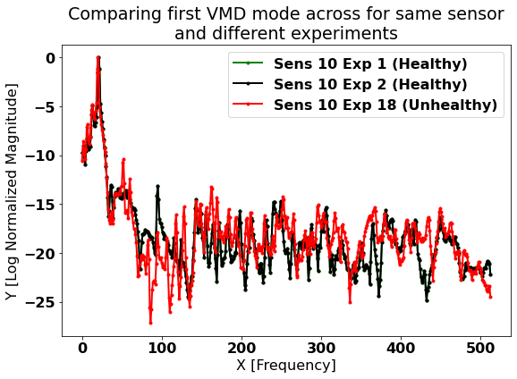

```python
plt.figure(figsize=(9,6))
plt.plot(building_features['Sensor10']['Experiment1'][0,:],'g.-',linewidth=2,label='Sens 10 Exp 1 (Healthy)')
plt.plot(building_features['Sensor10']['Experiment2'][0,:],'k.-',linewidth=2,label='Sens 10 Exp 2 (Healthy)')
plt.plot(building_features['Sensor10']['Experiment18'][0,:],'r.-',linewidth=2,label='Sens 10 Exp 18 (Unhealthy)')
plt.title('Comparing first VMD mode across for same sensor\nand different experiments');
plt.legend()

plt.xlabel('X [Frequency]')
plt.ylabel('Y [Log Normalized Magnitude]')
```

# Generating Matrix Profiles

Here we are re-arranging "building_features" dictionary to append experiments in sequence. This is because the matrix profile will be looking at the data sequentially (as a stream). In particular it works by a sliding norm window across the signal length, hence the need to sequence data.

**NOTE:** For efficiency many of the following loops can be condensed into one larger single loop. However, we purposely choose to separate out the loops for ease of understanding novel concepts

```python
building_features_seq = dict()

for i in range(1,num_sensors+1):
    sensor_str = f'Sensor{i}'

    stack_list = []
    for j in range(1,num_experiments+1):
        experiment_str = f'Experiment{j}'
        stack_list.append(building_features[sensor_str][experiment_str])

    building_features_seq[sensor_str] = np.hstack(stack_list)
```

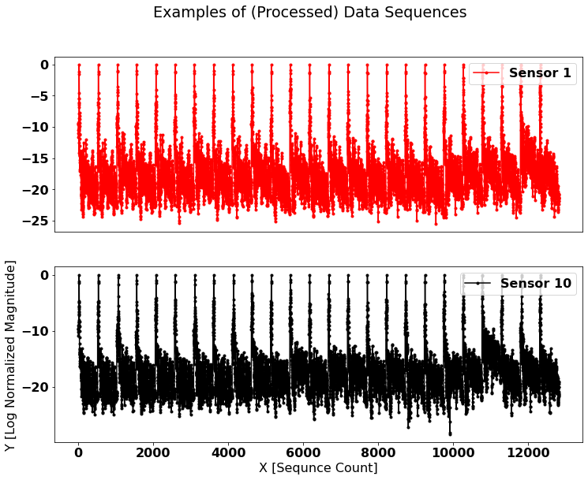

```python
# Each peak in the following graphs represents a new observation / experiment from the sensor
fig, (ax1, ax2) = plt.subplots(2, figsize=(12,9))
fig.suptitle('Examples of (Processed) Data Sequences')
ax1.plot(building_features_seq['Sensor1'][0],'r.-',label='Sensor 1')
ax1.set_xticks([])
ax1.legend(loc=1)
ax2.plot(building_features_seq['Sensor10'][0],'k.-',label='Sensor 10')
ax2.legend(loc=1)

ax2.set_ylabel('Y [Log Normalized Magnitude]');
ax2.set_xlabel('X [Sequnce Count]');
```

## Matrix Profile Loop

```python
time1 = time.time()

MP_period =building_features['Sensor1']['Experiment1'].shape[1] # Amount of data in one observation (513)

building_MP_CACs = dict() # Will store MPs and CACs for each of the 5 VMD modes, for each sensor
for i in range(1,num_sensors+1):
    sensor_str = f'Sensor{i}'

    mp_list = []
    cac_list = []
    building_MP_CACs[sensor_str] = dict()
    for vmd_num in range(num_modes):
        mp = stumpy.stump(building_features_seq[sensor_str][vmd_num], m=MP_period)
        mp_list.append(mp[:,0])

        cac = _cac(mp[:, 3], L=MP_period, bidirectional=False, excl_factor=1)
        cac_list.append(cac)

    building_MP_CACs[sensor_str]['MP'] = np.array(mp_list)
    building_MP_CACs[sensor_str]['CAC'] = np.array(cac_list)

    print(f'Processed Sensor {i}')

time2 = time.time()


print(f'Time Taken: {time2-time1}s.')
```

```
Processed Sensor 1
Processed Sensor 2
Processed Sensor 3
Processed Sensor 4
Processed Sensor 5
Processed Sensor 6
Processed Sensor 7
Processed Sensor 8
Processed Sensor 9
Processed Sensor 10
Processed Sensor 11
Processed Sensor 12
Processed Sensor 13
Processed Sensor 14
Processed Sensor 15
Processed Sensor 16
Processed Sensor 17
Processed Sensor 18
Processed Sensor 19
Processed Sensor 20
Processed Sensor 21
Processed Sensor 22
Processed Sensor 23
Processed Sensor 24
Time Taken: 317.37104511260986s.
```

# Pooling Data

Here we will use the optimal transport (OT) barycentre to pool together:

1. Each of the MP and CAC results, based on the VMD (of which there are five) results at each Sensor
2. Each of the previous MP and CAC results across all the sensors (of which there are 24)

We shall compare this against what the naive average would calcualte

### Pooling Across Each VMD Mode For Each Sensor

```python
sub_sample_rate = 10
for i in range(1,num_sensors+1):
    sensor_str = f'Sensor{i}'

    A = building_MP_CACs[sensor_str]['CAC'].T
    B = A[::sub_sample_rate,:] # Sub-sampling to increase OT processing
    M = ot.utils.dist0(B.shape[0]) # Ground Metric
    M /= M.max()  # Normalizing ground metric
    M*=1e+4 # Tuning ground metric for problem (hyper-param)
    bary_wass = ot.barycenter_unbalanced(B, M, reg=5e-4, reg_m=1e-1) # reg - Entropic Regularization
                                                                     # reg_m - Marginal Relaxation Factor

    building_MP_CACs[sensor_str]['CAC_OT'] = bary_wass
    building_MP_CACs[sensor_str]['CAC_AVG'] = np.mean(B, axis=1)

    print(f'Processed Sensor {i}')
```

```
Processed Sensor 1
Processed Sensor 2
Processed Sensor 3
Processed Sensor 4
Processed Sensor 5
Processed Sensor 6
Processed Sensor 7
Processed Sensor 8
Processed Sensor 9
Processed Sensor 10
Processed Sensor 11
Processed Sensor 12
Processed Sensor 13
Processed Sensor 14
Processed Sensor 15
Processed Sensor 16
Processed Sensor 17
Processed Sensor 18
Processed Sensor 19
Processed Sensor 20
Processed Sensor 21
Processed Sensor 22
Processed Sensor 23
Processed Sensor 24
```

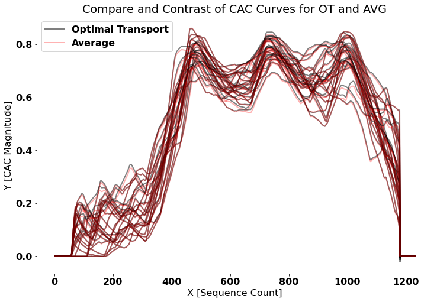

```python
# Display Results

OTs = []
AVGs = []
plt.figure(figsize=(12,8))
for i in range(1,25):
    sensor_str = f'Sensor{i}'
    AVGs.append(building_MP_CACs[sensor_str]['CAC_AVG'])
    OTs.append(building_MP_CACs[sensor_str]['CAC_OT'])
    # Visually nicer to display the (1-CAC) curve
    plt.plot(1-OTs[i-1],'k',alpha=0.5,  label= 'Optimal Transport' if i==1 else None, linewidth=2)
    plt.plot(1-AVGs[i-1],'r',alpha=0.3, label= 'Average' if i==1 else None, linewidth=2)

plt.legend()
plt.ylabel('Y [CAC Magnitude]')
plt.xlabel('X [Sequence Count]')
plt.title('Compare and Contrast of CAC Curves for OT and AVG');
```

### Pooling Across Each Sensor

```python
# Constructing Ground Metric
M = ot.utils.dist0(B.shape[0])
M /= M.max()
M *= 1e2 # Hyper-Param

# Final Pooling Here
final_OT = ot.barycenter_unbalanced(np.array(OTs).T, M, reg=2e-4, reg_m=9e-4)# reg - Entropic Regularization
                                                                             # reg_m - Marginal Relaxation Factor
final_AVG = np.array(AVGs).mean(axis=0)
```

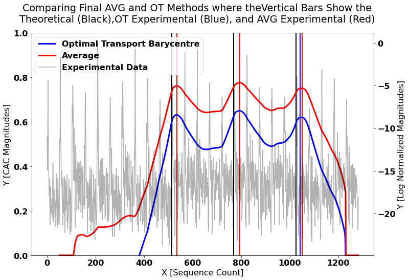

```python
# Plotting

fig, ax1 = plt.subplots(figsize=(12,8))
xs = np.arange(len(final_OT))
shift_factor = MP_period//sub_sample_rate # Need two correction factors (1) Matrix profile window (2) Sub-sampling
xs_shifted = xs + shift_factor  # Offset from MP (shift CAC curves by this amount to visually align with experiment)

# Plotting CAC Curves
plt1, = ax1.plot(xs_shifted, 1-final_OT,'b', linewidth=3, label='Optimal Transport Barycentre')
plt2, = ax1.plot(xs_shifted, 1-final_AVG,'r', linewidth=3, label='Average')
ax1.axis(ymin=0, ymax=1)
ax1.set_ylabel('Y [CAC Magnitudes]')
ax1.set_xlabel('X [Sequence Count]')
fig.suptitle('Comparing Final AVG and OT Methods where theVertical Bars Show the\nTheoretical (Black),\
OT Experimental (Blue), and AVG Experimental (Red)');

# Plotting Sensor 10 (and one of the VMD signals) behind for reference
ax2 = ax1.twinx()  # instantiate a second axes that shares the same x-axis
plt3, = ax2.plot(building_features_seq['Sensor10'][1][::sub_sample_rate],'k', alpha=0.3, label='Experimental Data')
ax2.set_ylabel('Y [Log Normalized Magnitudes]')

# Making Legend
lgd_list = [plt1, plt2, plt3]
ax1.legend(lgd_list, [lgd_list_.get_label() for lgd_list_ in lgd_list], loc='upper left');

# Observing the break point locations
theoretical_peaks = np.array([MP_period*10, MP_period*15, MP_period*20])//sub_sample_rate
AVG_peaks = np.array(find_peaks(1-final_AVG, height=0.7, distance=10)[0]) + shift_factor
OT_peaks = np.array(find_peaks(1-final_OT, height=0.5, distance=10)[0]) + shift_factor

# Displaying vertical bars for breakpoints
ax1.vlines(x = theoretical_peaks, ymin=0, ymax = 1, color='k', linewidth=2)
ax1.vlines(x = OT_peaks,  ymin=0, ymax = 1, color='b', linewidth=2)
ax1.vlines(x = AVG_peaks, ymin=0, ymax = 1, color='r', linewidth=2)
```

### Calculating Distance From Theoretical Vertical Bars

Calculated based on Hausdorff Metric

```python
from ruptures.metrics import hausdorff
signal_end = len(final_OT)
print(hausdorff(np.concatenate((theoretical_peaks,[signal_end])), np.concatenate((OT_peaks,[signal_end]))))
print(hausdorff(np.concatenate((theoretical_peaks,[signal_end])), np.concatenate((AVG_peaks,[signal_end]))))

# OT marginally better in getting closer to theoretical peak
# Both fail to an extent because there is always a lag between 'when damage happens'
# And 'when we can detect'.
# However evidently OT has less false positives for peak detection (as noted by early rising by AVG)
```

```
24.0
25.0
```

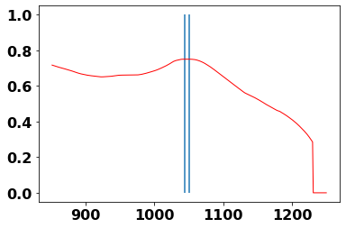

```python
# Me studying something - ignore
plt.plot(xs_shifted[800:1200], (1-final_AVG)[800:1200],'r', linewidth=1, label='Average')
plt.vlines([1044, 1050], ymin=0,ymax=1)
```

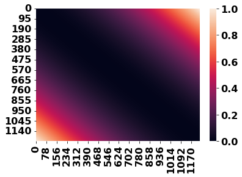

```python
# Ground Metric Cost Map
# Random Stuff
# Me studying something - ignore

import seaborn as sns
sns.heatmap(M/M.max())
```